# Result(3)

Preview

Hiroki Kato

## 2019年度クーポン券送付対象外の男性に限定したナッジ・メッセージの効果

Table 1: Wave 1セレクションデータの共変量のバランステスト（2019年度クーポン券配布対外）

|  | Treatments 厚労省 | Treatments 年齢表現 | Treatments 利他強調 | Treatments 利己強調 | Treatments 社会比較 | Treatments 有効期限 | Treatments 低コスト | p-value |
| --- | --- | --- | --- | --- | --- | --- | --- | --- |
| age | 51.632 | 51.408 | 51.226 | 51.657 | 51.582 | 51.545 | 51.502 | 0.712 |
| avoid_crowd | 3.307 | 3.378 | 3.429 | 3.250 | 3.306 | 3.296 | 3.455 | 0.354 |
| avoid_out | 2.903 | 2.917 | 2.919 | 2.884 | 2.825 | 2.966 | 2.982 | 0.848 |
| education | 14.572 | 14.655 | 14.530 | 14.830 | 14.566 | 14.634 | 14.393 | 0.578 |
| exercise_w1 | 0.156 | 0.193 | 0.239 | 0.230 | 0.183 | 0.203 | 0.218 | 0.252 |
| flushot | 0.228 | 0.244 | 0.197 | 0.270 | 0.275 | 0.228 | 0.251 | 0.433 |
| handicap | 0.596 | 0.630 | 0.607 | 0.617 | 0.574 | 0.626 | 0.619 | 0.881 |
| handwash | 3.803 | 3.883 | 3.900 | 3.778 | 3.817 | 3.833 | 3.892 | 0.827 |
| health_check | 0.632 | 0.664 | 0.701 | 0.683 | 0.653 | 0.659 | 0.644 | 0.742 |
| married | 0.600 | 0.588 | 0.628 | 0.657 | 0.602 | 0.549 | 0.619 | 0.334 |
| prob_social | 26.920 | 31.387 | 30.983 | 28.522 | 29.442 | 27.846 | 31.925 | 0.025 |
| severity | 0.920 | 0.933 | 0.919 | 0.970 | 0.940 | 0.931 | 0.908 | 0.046 |
| temp_check | 2.139 | 2.248 | 2.210 | 2.083 | 2.192 | 2.086 | 2.270 | 0.490 |
| wear_mask | 3.071 | 3.191 | 3.157 | 3.148 | 2.961 | 2.966 | 3.068 | 0.447 |

Table 2: Wave 1セレクションデータの共変量のバランステスト（2019年度クーポン券配布対象外）

|  | Treatments 厚労省 | Treatments 年齢表現 | Treatments 利他強調 | Treatments 利己強調 | Treatments 社会比較 | Treatments 有効期限 | Treatments 低コスト | p-value |
| --- | --- | --- | --- | --- | --- | --- | --- | --- |
| age | 51.695 | 51.394 | 51.179 | 51.662 | 51.421 | 51.605 | 51.512 | 0.564 |
| avoid_crowd | 3.295 | 3.361 | 3.447 | 3.239 | 3.313 | 3.309 | 3.433 | 0.437 |
| avoid_out | 2.886 | 2.889 | 2.932 | 2.866 | 2.855 | 2.964 | 2.941 | 0.960 |
| education | 14.505 | 14.620 | 14.553 | 14.876 | 14.593 | 14.610 | 14.345 | 0.472 |
| exercise_w1 | 0.159 | 0.194 | 0.232 | 0.229 | 0.173 | 0.211 | 0.202 | 0.432 |
| flushot | 0.223 | 0.245 | 0.189 | 0.264 | 0.280 | 0.215 | 0.241 | 0.376 |
| handicap | 0.609 | 0.634 | 0.637 | 0.617 | 0.584 | 0.628 | 0.606 | 0.936 |
| handwash | 3.823 | 3.889 | 3.926 | 3.751 | 3.836 | 3.861 | 3.867 | 0.769 |
| health_check | 0.632 | 0.667 | 0.684 | 0.677 | 0.645 | 0.673 | 0.631 | 0.849 |
| married | 0.591 | 0.560 | 0.611 | 0.652 | 0.598 | 0.547 | 0.596 | 0.407 |
| prob_social | 27.409 | 31.296 | 30.368 | 29.055 | 30.187 | 28.072 | 32.118 | 0.130 |
| severity | 0.923 | 0.935 | 0.926 | 0.970 | 0.935 | 0.933 | 0.921 | 0.171 |
| temp_check | 2.095 | 2.204 | 2.221 | 2.100 | 2.136 | 2.085 | 2.182 | 0.841 |
| wear_mask | 3.082 | 3.176 | 3.116 | 3.144 | 2.977 | 2.942 | 3.010 | 0.533 |

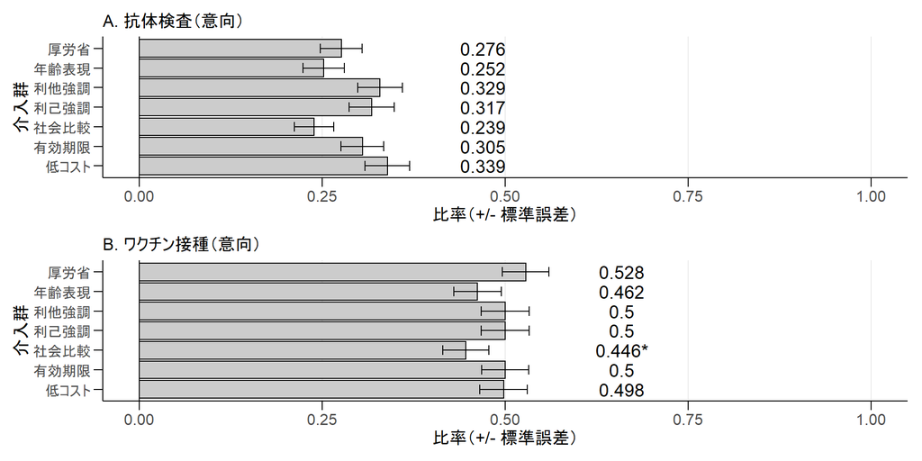

Figure 1: 2019年度クーポン券配布対象外の男性に限定した意向に対するナッジ・メッセージの効果。データソース：Wave 1セレクションデータ。注）図中の数値は各群の比率を示す。星印は厚労省メッセージ群との平均値の差のt検定の結果であり、次の規則に従う：* p < 0.1、** p < 0.05、*** p < 0.01。

また、社会比較メッセージは抗体検査受検の意向に対して統計的に有意な効果を持っていないが、 ワクチン接種の意向に対して負の効果を持っている。 厚労省メッセージを読んだ人の抗体検査受検とワクチン接種の意向の比率はそれぞれ約27.6%と約52.8%である。 それに対して、社会比較メッセージを読んだ人の抗体検査受検とワクチン接種の意向の比率はそれぞれ 約23.9%と約44.6%である。 したがって、社会比較メッセージの抗体検査受検の意向に対する効果は約-3.7%ポイントであり、 これは統計的に有意な効果ではない。 しかしながら、社会比較メッセージのワクチン接種の意向に対する効果は約-8.2%ポイントであり、 これは統計的に10%水準で有意である。

この負の効果の原因の一つとして、ワクチン接種のただ乗りが挙げられる。 社会比較メッセージは「5人に1人が抗体を持っていない」ことを強調している。 裏返せば、5人に4人が抗体を持っているということである。 このメッセージを読んだ人は、仮に風しんの抗体を保有していないとしても、 全体の80%が抗体を持っているので、自身が感染する機会は少ないと考えたのかもしれない。 クーポン券がない場合、 この信念がワクチンを接種することの価値を低め、 ワクチン接種の意向の比率をコントロールよりも下げた可能性がある。

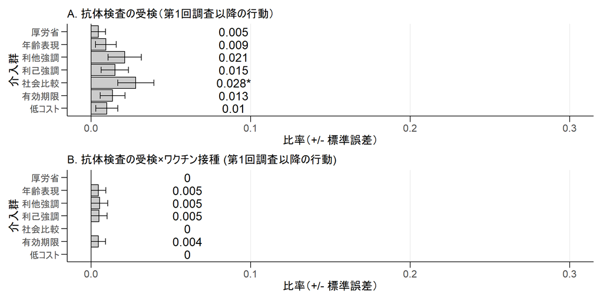

Figure 2: 2019年度クーポン券配布対象外の男性に限定した行動に対するナッジ・メッセージの効果。データソース：Wave 2セレクションデータ。注）図中の数値は各群の比率を示す。星印は厚労省メッセージ群との平均値の差のt検定の結果であり、次の規則に従う：* p < 0.1、** p < 0.05、*** p < 0.01。

図2は各介入群の第1回調査以降の抗体検査受検比率と 第1回調査以降のワクチン接種比率である。 社会比較メッセージが厚労省メッセージよりも第1回調査以降の抗体検査の受検を促進しているが、 抗体検査とワクチン接種の両方を促進していない。 厚労省メッセージを読んだ人の約0.5%が第1回調査以降に抗体検査を受検したが、 誰もワクチン接種をしていない。 また、社会比較メッセージを読んだ人の約2.8%が第1回調査以降に抗体検査を受検したが、 誰もワクチン接種をしていない。 よって、社会比較メッセージの抗体検査受検に対する効果は約2.3%ポイントであり、 これは統計的に10%水準で有意である。 しかしながら、抗体検査とワクチン接種の両方に対する効果はゼロである。

Table 3: 2019年度クーポン券配布対象外の男性に限定した 抗体検査とワクチン接種の意向の線形確率モデルの推定結果

抗体検査

ワクチン接種

年齢表現

－0.024

－0.036

－0.066

－0.101**

(0.040)

(0.038)

(0.045)

(0.043)

利他強調

0.053

0.053

－0.028

－0.059

(0.042)

(0.042)

(0.045)

(0.045)

利己強調

0.041

0.026

－0.028

－0.053

(0.042)

(0.040)

(0.046)

(0.043)

社会比較

－0.037

－0.043

－0.082*

－0.098**

(0.039)

(0.038)

(0.045)

(0.042)

有効期限

0.029

0.029

－0.028

－0.043

(0.041)

(0.039)

(0.045)

(0.042)

低コスト

0.063

0.034

－0.030

－0.052

(0.042)

(0.040)

(0.045)

(0.043)

Num.Obs.

1688

1578

1688

1578

R2

0.298

0.367

0.492

0.550

R2 Adj.

0.295

0.358

0.490

0.544

共変量

X

X

Table 4: 2019年度クーポン券配布対象外の男性に限定した 抗体検査とワクチン接種の行動の線形確率モデルの推定結果

抗体検査

抗体検査×ワクチン接種

年齢表現

0.005

0.004

0.005

0.005

(0.008)

(0.008)

(0.005)

(0.005)

利他強調

0.017

0.016

0.005

0.005

(0.011)

(0.011)

(0.005)

(0.005)

利己強調

0.010

0.009

0.005

0.005

(0.010)

(0.010)

(0.005)

(0.005)

社会比較

0.023*

0.022*

0.000

0.000

(0.012)

(0.012)

(0.001)

有効期限

0.009

0.009

0.004

0.005

(0.009)

(0.009)

(0.004)

(0.005)

低コスト

0.005

0.006

0.000

0.000

(0.008)

(0.008)

(0.001)

Num.Obs.

1467

1467

1467

1467

R2

0.018

0.033

0.005

0.015

R2 Adj.

0.013

0.019

0.000

0.001

共変量

X

X

Table 5: 2019年度クーポン券配布対象外の抗体検査受検者の動き

| Treatments | Negative antibody No | Negative antibody Yes | Vaccination No | Vaccination Yes |
| --- | --- | --- | --- | --- |
| 厚労省 | 1 | 0 | 1 | 0 |
| 年齢表現 | 0 | 2 | 1 | 1 |
| 利他強調 | 3 | 1 | 3 | 1 |
| 利己強調 | 2 | 1 | 2 | 1 |
| 社会比較 | 5 | 1 | 6 | 0 |
| 有効期限 | 2 | 1 | 2 | 1 |
| 低コスト | 2 | 0 | 2 | 0 |

Note: Fisher exact test (Outcome: Negative antibody): p = 0.466. Fisher exact test (Outcome: Vaccination): p = 0.568.